# 重賞レース予測レポート【レース終了】

作成日時: 2026/03/08 16:19:58

☞ [マニュアル(pdf)](https://ryutoro-galois.github.io/keiba-predictor/manual/manual.pdf)

☞ 過去6年の同一レース結果: [2025年](https://ryutoro-galois.github.io/keiba-predictor/report/PredResult_2025y_raceDate_20250308_20250309.html), [2024年](https://ryutoro-galois.github.io/keiba-predictor/report/PredResult_2024y_raceDate_20240302_20240303.html), [2023年](https://ryutoro-galois.github.io/keiba-predictor/report/PredResult_2023y_raceDate_20230304_20230305.html), [2022年](https://ryutoro-galois.github.io/keiba-predictor/report/PredResult_2022y_raceDate_20220305_20220306.html), [2021年](https://ryutoro-galois.github.io/keiba-predictor/report/PredResult_2021y_raceDate_20210306_20210307.html), [2020年](https://ryutoro-galois.github.io/keiba-predictor/report/PredResult_2020y_raceDate_20200307_20200308.html)

☞ 過去4週間の別レース結果: [1週前(2/28-3/1)](https://ryutoro-galois.github.io/keiba-predictor/report/PredResult_2026y_raceDate_20260228_20260301.html), [2週前(2/21-22)](https://ryutoro-galois.github.io/keiba-predictor/report/PredResult_2026y_raceDate_20260221_20260222.html), [3週前(2/14-15)](https://ryutoro-galois.github.io/keiba-predictor/report/PredResult_2026y_raceDate_20260214_20260215.html), [4週前(2/8)](https://ryutoro-galois.github.io/keiba-predictor/report/PredResult_2026y_raceDate_20260208_20260208.html)

☞ netkeiba: [中山牝馬ステークス(GⅢ)](https://race.netkeiba.com/race/result.html?race_id=202606020311&rf=race_submenu), [フィリーズレビュー(GⅡ)](https://race.netkeiba.com/race/result.html?race_id=202609010511&rf=race_submenu), [弥生賞ディープインパクト記念(GⅡ)](https://race.netkeiba.com/race/result.html?race_id=202606020411&rf=race_submenu)

☞ レース結果(csv): [3/7-8](https://ryutoro-galois.github.io/keiba-predictor/csv/race_result_20260307_20260308.csv)

## 【レース結果(1)】人気と着順の関係

### 【中山牝馬ステークス(2026/03/07(土))】

【中山牝馬ステークス(GⅢ)】  
2026/03/07(土), 06_中山, 芝右1800m

[interactive chart not shown]

### 【フィリーズレビュー(2026/03/07(土))】

【フィリーズレビュー(GⅡ)】  
2026/03/07(土), 09_阪神, 芝右1400m

[interactive chart not shown]

### 【弥生賞ディープインパクト記念(2026/03/08(日))】

【弥生賞ディープインパクト記念(GⅡ)】  
2026/03/08(日), 06_中山, 芝右2000m

[interactive chart not shown]

## 【レース結果(2)】コーナー通過順位

### 【中山牝馬ステークス(2026/03/07(土))】

【中山牝馬ステークス(GⅢ)】  
2026/03/07(土), 06_中山, 芝右1800m

[interactive chart not shown]

### 【フィリーズレビュー(2026/03/07(土))】

【フィリーズレビュー(GⅡ)】  
2026/03/07(土), 09_阪神, 芝右1400m

[interactive chart not shown]

### 【弥生賞ディープインパクト記念(2026/03/08(日))】

【弥生賞ディープインパクト記念(GⅡ)】  
2026/03/08(日), 06_中山, 芝右2000m

[interactive chart not shown]

## 0. 推し馬予測 (AI予測)

### 【中山牝馬ステークス(GⅢ) 2026/03/07(土)】

- 本命(◎): 1-3着内確率(勝負強さ)が1位の馬
- 対抗(◯): 1-3着内確率が2-N位(20%程度以上)の中で予測タイムが最も速い馬
- 3番手(▲): 1-3着内確率が2-N位(20%程度以上)のでダークホース確率が最も高い馬
- 穴: ダークホース確率が上位1-M位(40%程度以上)の中で1-3着内確率が最も高い馬

| 推し馬 | 枠番 | 馬番 | 人気 | オッズ | 馬名 | 騎手 | 調教師 | 予測タイム(sec) | 1_順位 | 1-3着内確率(%) | 2_順位 | ﾀﾞｰｸﾎｰｽ確率(%) | 3_順位 |
| --- | --- | --- | --- | --- | --- | --- | --- | --- | --- | --- | --- | --- | --- |
| 本命(◎) | 2 | 4 | 3 | 5.3 | パラディレーヌ | 岩田望来 | 千田輝彦 | 111.2 | 8 | 58.4 | 1 | 0.4 | 14.0 |
| 対抗(◯) | 5 | 10 | 1 | 4.2 | アンゴラブラック | 戸崎圭太 | 尾関知人 | 105.4 | 1 | 20.8 | 6 | 0.4 | 15.5 |
| 3番手(▲) | 3 | 5 | 5 | 13.0 | ボンドガール | 岩田康誠 | 手塚貴久 | 109.9 | 2 | 38.0 | 3 | 1.3 | 10.0 |
| 穴 | 6 | 11 | 15 | 136.2 | フィールシンパシー | 横山琉人 | 小島茂之 | 113.2 | 11 | 5.4 | 13 | 45.6 | 2.0 |

### 【フィリーズレビュー(GⅡ) 2026/03/07(土)】

- 本命(◎): 1-3着内確率(勝負強さ)が1位の馬
- 対抗(◯): 1-3着内確率が2-N位(20%程度以上)の中で予測タイムが最も速い馬
- 3番手(▲): 1-3着内確率が2-N位(20%程度以上)のでダークホース確率が最も高い馬
- 穴: ダークホース確率が上位1-M位(40%程度以上)の中で1-3着内確率が最も高い馬

| 推し馬 | 枠番 | 馬番 | 人気 | オッズ | 馬名 | 騎手 | 調教師 | 予測タイム(sec) | 1_順位 | 1-3着内確率(%) | 2_順位 | ﾀﾞｰｸﾎｰｽ確率(%) | 3_順位 |
| --- | --- | --- | --- | --- | --- | --- | --- | --- | --- | --- | --- | --- | --- |
| 本命(◎) | 8 | 17 | 2 | 5.4 | サンアントワーヌ | 荻野極 | 鹿戸雄一 | 84.0 | 11.0 | 40.4 | 1 | 0.5 | 18 |
| 対抗(◯) | 3 | 5 | 3 | 5.7 | テイエムスティール | 高杉吏麒 | 高橋一哉 | 92.7 | 16.0 | 24.8 | 2 | 0.6 | 16 |
| 3番手(▲) | 4 | 8 | 6 | 16.2 | ルージュサウダージ | 斎藤新 | 松永幹夫 | 92.9 | 18.0 | 23.8 | 3 | 1.0 | 13 |
| 穴 | 1 | 1 | 17 | 92.3 | フルールジェンヌ | 永島まなみ | 鈴木孝志 | 82.5 | 3.5 | 8.0 | 10 | 44.0 | 2 |

### 【弥生賞ディープインパクト記念(GⅡ) 2026/03/08(日)】

- 本命(◎): 1-3着内確率(勝負強さ)が1位の馬
- 対抗(◯): 1-3着内確率が2-N位(20%程度以上)の中で予測タイムが最も速い馬
- 3番手(▲): 1-3着内確率が2-N位(20%程度以上)のでダークホース確率が最も高い馬
- 穴: ダークホース確率が上位1-M位(40%程度以上)の中で1-3着内確率が最も高い馬

| 推し馬 | 枠番 | 馬番 | 人気 | オッズ | 馬名 | 騎手 | 調教師 | 予測タイム(sec) | 1_順位 | 1-3着内確率(%) | 2_順位 | ﾀﾞｰｸﾎｰｽ確率(%) | 3_順位 |
| --- | --- | --- | --- | --- | --- | --- | --- | --- | --- | --- | --- | --- | --- |
| 本命(◎) | 4 | 4 | 2 | 3.4 | ライヒスアドラー | 佐々木大輔 | 上原佑紀 | 132.2 | 4 | 24.0 | 1 | 0.7 | 9 |
| 対抗(◯) | 6 | 6 | 1 | 2.4 | アドマイヤクワッズ | 坂井瑠星 | 友道康夫 | 119.9 | 1 | 20.8 | 2 | 0.7 | 10 |
| 3番手(▲) | 8 | 10 | 6 | 16.4 | バリオス | 高杉吏麒 | 武幸四郎 | 132.1 | 3 | 13.4 | 5 | 55.8 | 1 |
| 穴 | 2 | 2 | 8 | 38.2 | メイショウソラリス | 角田大和 | 角田晃一 | 132.0 | 2 | 10.4 | 7 | 52.0 | 2 |

## 1. 予測チャート (タイム/勝負強さ)

### 【中山牝馬ステークス(GⅢ)】

2026/03/07(土), 06_中山, 芝右1800m

[interactive chart not shown]

### 【フィリーズレビュー(GⅡ)】

2026/03/07(土), 09_阪神, 芝右1400m

[interactive chart not shown]

### 【弥生賞ディープインパクト記念(GⅡ)】

2026/03/08(日), 06_中山, 芝右2000m

[interactive chart not shown]

## 2. オッズモニタリング (毎時)

### 【中山牝馬ステークス】

[interactive chart not shown]

### 【フィリーズレビュー】

[interactive chart not shown]

### 【弥生賞ディープインパクト記念】

[interactive chart not shown]

## 3. 出馬表

### 【中山牝馬ステークス 2026/03/07(土) 】

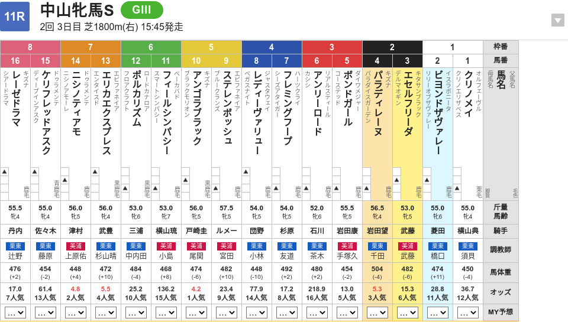

### 【フィリーズレビュー 2026/03/07(土) 】

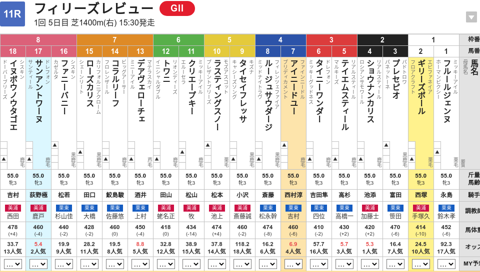

### 【弥生賞ディープインパクト記念 2026/03/08(日) 】

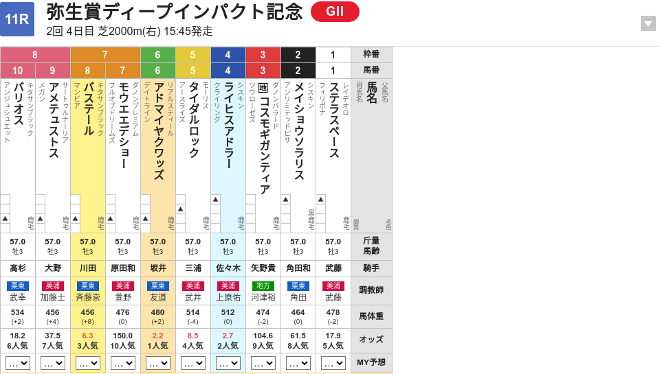

## 4. 単勝予測結果

### 【中山牝馬ステークス(GⅢ) 2026/03/07(土)】

| 枠番 | 馬番 | 人気 | オッズ | 馬名 | 騎手 | 調教師 | 予測タイム(sec) | 1_順位 | 1-3着内確率(%) | 2_順位 | ﾀﾞｰｸﾎｰｽ確率(%) | 3_順位 |
| --- | --- | --- | --- | --- | --- | --- | --- | --- | --- | --- | --- | --- |
| 1 | 1 | 12 | 36.7 | クリノメイ | 横山典弘 | 須貝尚介 | 110.4 | 4 | 8.8 | 9 | 39.5 | 4.0 |
| 1 | 2 | 11 | 28.8 | ビヨンドザヴァレー | 菱田裕二 | 橋口慎介 | 110.1 | 3 | 12.5 | 7 | 39.5 | 3.0 |
| 2 | 3 | 6 | 15.3 | エセルフリーダ | 武藤雅 | 武藤善則 | 117.4 | 16 | 7.5 | 10 | 1.6 | 9.0 |
| 2 | 4 | 3 | 5.3 | パラディレーヌ | 岩田望来 | 千田輝彦 | 111.2 | 8 | 58.4 | 1 | 0.4 | 14.0 |
| 3 | 5 | 5 | 13.0 | ボンドガール | 岩田康誠 | 手塚貴久 | 109.9 | 2 | 38.0 | 3 | 1.3 | 10.0 |
| 3 | 6 | 16 | 218.9 | アンリーロード | 石川裕紀人 | 茶木太樹 | 115.8 | 14 | 4.4 | 15 | 16.2 | 7.0 |
| 4 | 7 | 8 | 17.2 | フレミングフープ | 杉原誠人 | 友道康夫 | 113.2 | 12 | 6.4 | 11 | 1.0 | 12.0 |
| 4 | 8 | 14 | 77.9 | レディーヴァリュー | 団野大成 | 小林真也 | 117.0 | 15 | 1.6 | 16 | 50.9 | 1.0 |
| 5 | 9 | 9 | 23.4 | ステレンボッシュ | Ｃ．ルメール | 宮田敬介 | 112.4 | 9 | 11.4 | 8 | 28.3 | 6.0 |
| 5 | 10 | 1 | 4.2 | アンゴラブラック | 戸崎圭太 | 尾関知人 | 105.4 | 1 | 20.8 | 6 | 0.4 | 15.5 |

[output cut: 6 more lines]

### 【フィリーズレビュー(GⅡ) 2026/03/07(土)】

| 枠番 | 馬番 | 人気 | オッズ | 馬名 | 騎手 | 調教師 | 予測タイム(sec) | 1_順位 | 1-3着内確率(%) | 2_順位 | ﾀﾞｰｸﾎｰｽ確率(%) | 3_順位 |
| --- | --- | --- | --- | --- | --- | --- | --- | --- | --- | --- | --- | --- |
| 1 | 1 | 17 | 92.3 | フルールジェンヌ | 永島まなみ | 鈴木孝志 | 82.5 | 3.5 | 8.0 | 10 | 44.0 | 2 |
| 1 | 2 | 10 | 24.5 | ギリーズボール | 西塚洸二 | 手塚貴久 | 81.0 | 1.5 | 10.6 | 7 | 32.9 | 4 |
| 2 | 3 | 7 | 16.4 | プレセピオ | 富田暁 | 笹田和秀 | 82.6 | 5.0 | 16.1 | 4 | 1.2 | 11 |
| 2 | 4 | 1 | 5.3 | ショウナンカリス | 池添謙一 | 加藤士津八 | 81.0 | 1.5 | 13.9 | 5 | 0.6 | 17 |
| 3 | 5 | 3 | 5.7 | テイエムスティール | 高杉吏麒 | 高橋一哉 | 92.7 | 16.0 | 24.8 | 2 | 0.6 | 16 |
| 3 | 6 | 16 | 57.7 | タイニーワンダー | 吉田隼人 | 四位洋文 | 86.7 | 12.0 | 5.1 | 16 | 54.5 | 1 |
| 4 | 7 | 4 | 6.9 | アイニードユー | 西村淳也 | 吉村圭司 | 92.1 | 13.0 | 12.7 | 6 | 0.6 | 15 |
| 4 | 8 | 6 | 16.2 | ルージュサウダージ | 斎藤新 | 松永幹夫 | 92.9 | 18.0 | 23.8 | 3 | 1.0 | 13 |
| 5 | 9 | 18 | 118.2 | タイセイフレッサ | 小沢大仁 | 斎藤誠 | 82.5 | 3.5 | 5.9 | 11 | 41.8 | 3 |
| 5 | 10 | 14 | 37.8 | ラスティングスノー | 松本大輝 | 池上昌和 | 82.7 | 6.0 | 5.3 | 14 | 32.8 | 5 |

[output cut: 8 more lines]

### 【弥生賞ディープインパクト記念(GⅡ) 2026/03/08(日)】

| 枠番 | 馬番 | 人気 | オッズ | 馬名 | 騎手 | 調教師 | 予測タイム(sec) | 1_順位 | 1-3着内確率(%) | 2_順位 | ﾀﾞｰｸﾎｰｽ確率(%) | 3_順位 |
| --- | --- | --- | --- | --- | --- | --- | --- | --- | --- | --- | --- | --- |
| 1 | 1 | 5 | 12.7 | ステラスペース | 武藤雅 | 武藤善則 | 132.5 | 6 | 11.7 | 6 | 1.5 | 6 |
| 2 | 2 | 8 | 38.2 | メイショウソラリス | 角田大和 | 角田晃一 | 132.0 | 2 | 10.4 | 7 | 52.0 | 2 |
| 3 | 3 | 9 | 53.4 | コスモギガンティア | 矢野貴之 | 河津裕昭 | 132.5 | 7 | 4.5 | 9 | 34.0 | 4 |
| 4 | 4 | 2 | 3.4 | ライヒスアドラー | 佐々木大輔 | 上原佑紀 | 132.2 | 4 | 24.0 | 1 | 0.7 | 9 |
| 5 | 5 | 4 | 7.2 | タイダルロック | 三浦皇成 | 武井亮 | 132.6 | 8 | 13.6 | 4 | 1.0 | 7 |
| 6 | 6 | 1 | 2.4 | アドマイヤクワッズ | 坂井瑠星 | 友道康夫 | 119.9 | 1 | 20.8 | 2 | 0.7 | 10 |
| 7 | 7 | 10 | 83.8 | モウエエデショー | 原田和真 | 萱野浩二 | 133.2 | 10 | 4.2 | 10 | 21.4 | 5 |
| 7 | 8 | 3 | 5.8 | バステール | 川田将雅 | 斉藤崇史 | 132.6 | 9 | 18.7 | 3 | 1.0 | 8 |
| 8 | 9 | 7 | 24.2 | アメテュストス | 大野拓弥 | 加藤士津八 | 132.3 | 5 | 6.0 | 8 | 50.6 | 3 |
| 8 | 10 | 6 | 16.4 | バリオス | 高杉吏麒 | 武幸四郎 | 132.1 | 3 | 13.4 | 5 | 55.8 | 1 |

## 5. 人気と着順の乖離率推移

### 【中山牝馬ステークス_1990y_2019y】

[interactive chart not shown]

### 【フィリーズレビュー_2001y_2019y】

[interactive chart not shown]

### 【弥生賞ディープインパクト記念_1990y_2019y】

[interactive chart not shown]

### 【中山牝馬ステークス_1990y_2019y】

| No | 開催年 | 不整合率(%) | 頭数 | 人気別着順(1-3位) | 人気別着順(全体) |
| --- | --- | --- | --- | --- | --- |
| 30 | 2019 | 56.9 | 14頭 | 5-3-11 | 5\|3\|11\|12\|7\|8\|1\|13\|14\|4\|9\|10\|6\|2 |
| 29 | 2018 | 58.0 | 14頭 | 6-2-9 | 6\|2\|9\|3\|13\|10\|8\|7\|11\|5\|4\|1\|12\|14 |
| 28 | 2017 | 28.9 | 16頭 | 5-1-7 | 5\|1\|7\|2\|6\|10\|11\|4\|8\|3\|12\|9\|14\|13\|16\|15 |
| 27 | 2016 | 37.3 | 16頭 | 4-1-15 | 4\|1\|15\|13\|3\|12\|16\|2\|14\|8\|11\|5\|9\|10\|6\|7 |
| 26 | 2015 | 48.6 | 14頭 | 3-4-5 | 3\|4\|5\|12\|1\|13\|14\|7\|6\|2\|11\|9\|10\|8 |
| 25 | 2014 | 33.5 | 16頭 | 1-10-4 | 1\|10\|4\|3\|5\|8\|9\|11\|12\|2\|16\|14\|6\|13\|7\|15 |
| 24 | 2013 | 28.7 | 16頭 | 6-2-1 | 6\|2\|1\|4\|3\|5\|10\|11\|8\|12\|7\|15\|16\|9\|13\|14 |
| 23 | 2012 | 44.9 | 16頭 | 8-7-11 | 8\|7\|11\|12\|2\|5\|9\|3\|1\|14\|4\|16\|15\|6\|10\|13 |
| 22 | 2011 | 26.1 | 18頭 | 10-14-13 | 10\|14\|13\|9\|18\|16\|11\|1\|2\|3\|5\|15\|12\|7\|8\|17\|6\|4 |
| 21 | 2010 | 42.4 | 16頭 | 4-8-9 | 4\|8\|9\|1\|11\|7\|6\|5\|2\|16\|15\|3\|14\|12\|10\|13 |

[output cut: 20 more lines]

### 【フィリーズレビュー_2001y_2019y】

| No | 開催年 | 不整合率(%) | 頭数 | 人気別着順(1-3位) | 人気別着順(全体) |
| --- | --- | --- | --- | --- | --- |
| 19 | 2019 | 52.3 | 18頭 | 12-3-6 | 12\|3\|6\|9\|5\|13\|1\|15\|7\|4\|2\|16\|18\|11\|8\|14\|10\|17 |
| 18 | 2018 | 46.9 | 17頭 | 8-2-5 | 8\|2\|5\|3\|14\|6\|9\|17\|16\|1\|10\|11\|13\|12\|7\|15\|18 |
| 17 | 2017 | 25.7 | 18頭 | 2-1-6 | 2\|1\|6\|3\|11\|8\|13\|12\|9\|18\|16\|14\|15\|4\|5\|7\|10\|17 |
| 16 | 2016 | 23.5 | 18頭 | 8-1-2 | 8\|1\|2\|4\|10\|7\|13\|5\|17\|15\|11\|12\|16\|14\|18\|3\|6\|9 |
| 15 | 2015 | 23.4 | 18頭 | 1-7-2 | 1\|7\|2\|8\|4\|9\|5\|10\|16\|13\|15\|6\|11\|18\|12\|3\|14\|17 |
| 14 | 2014 | 34.4 | 16頭 | 2-13-6 | 2\|13\|6\|7\|1\|5\|11\|3\|4\|16\|12\|14\|10\|9\|8\|15 |
| 13 | 2013 | 62.7 | 16頭 | 3-4-11 | 3\|4\|11\|6\|5\|13\|2\|9\|16\|14\|1\|15\|12\|10\|8\|7 |
| 12 | 2012 | 22.8 | 16頭 | 1-8-7 | 1\|8\|7\|2\|10\|4\|5\|15\|3\|12\|14\|6\|13\|9\|16\|11 |
| 11 | 2011 | 44.2 | 16頭 | 3-6-5 | 3\|6\|5\|1\|12\|13\|2\|10\|9\|4\|7\|11\|16\|14\|8\|15 |
| 10 | 2010 | 35.7 | 16頭 | 9-1-5 | 9\|1\|5\|4\|7\|11\|14\|6\|15\|10\|13\|2\|3\|8\|12\|16 |

[output cut: 9 more lines]

### 【弥生賞ディープインパクト記念_1990y_2019y】

| No | 開催年 | 不整合率(%) | 頭数 | 人気別着順(1-3位) | 人気別着順(全体) |
| --- | --- | --- | --- | --- | --- |
| 30 | 2019 | 51.0 | 10頭 | 8-6-4 | 8\|6\|4\|1\|3\|5\|2\|9\|7\|10 |
| 29 | 2018 | 13.0 | 10頭 | 1-2-4 | 1\|2\|4\|5\|6\|7\|3\|10\|8\|9 |
| 28 | 2017 | 44.3 | 12頭 | 1-8-5 | 1\|8\|5\|7\|6\|3\|9\|4\|2\|10\|11\|12 |
| 27 | 2016 | 14.0 | 12頭 | 2-1-3 | 2\|1\|3\|4\|5\|12\|6\|7\|11\|8\|10\|9 |
| 26 | 2015 | 49.2 | 11頭 | 2-4-10 | 2\|4\|10\|7\|3\|5\|1\|8\|6\|9\|11 |
| 25 | 2014 | 16.9 | 13頭 | 1-4-2 | 1\|4\|2\|8\|3\|5\|11\|6\|10\|12\|13\|9\|7 |
| 24 | 2013 | 27.7 | 12頭 | 6-10-2 | 6\|10\|2\|1\|3\|4\|7\|8\|11\|9\|5\|12 |
| 23 | 2012 | 58.0 | 15頭 | 9-3-5 | 9\|3\|5\|12\|6\|2\|7\|1\|4\|13\|10\|11\|15\|8\|14 |
| 22 | 2011 | 49.0 | 11頭 | 1-7-5 | 1\|7\|5\|4\|10\|8\|6\|3\|9\|11\|2 |
| 21 | 2010 | 26.7 | 13頭 | 1-2-7 | 1\|2\|7\|6\|8\|13\|5\|12\|4\|10\|3\|11\|9 |

[output cut: 20 more lines]

## 6. 1-3番人気馬の着順分類予測

### 【中山牝馬ステークス】

| 分類 | 凡例 | 発生確率(%) | 当該レース | 当該レースランク | 直近1年間 |
| --- | --- | --- | --- | --- | --- |
| 8: 1,2,3番人気すべて着外 (8_darkhorse) | * \| * \| * | 21.9 | 0.66 | 0.66 | 0.33 |
| 1: 1番人気のみ (1_pop1) | 1 \| * \| * | 16.2 | 0.65 | 0.65 | 0.00 |
| 4: 1,2番人気のみ (4_pop12) | 1 \| 2 \| * | 15.1 | 1.82 | 1.82 | 0.00 |
| 5: 1,3番人気のみ (5_pop13) | 1 \| 3 \| * | 12.4 | 4.43 | 4.43 | 0.00 |
| 3: 3番人気のみ (3_pop3) | 3 \| * \| * | 10.2 | 0.61 | 0.61 | 0.31 |
| 2: 2番人気のみ (2_pop2) | 2 \| * \| * | 8.6 | 3.07 | 3.07 | 0.00 |
| 6: 2,3番人気のみ (6_pop23) | 2 \| 3 \| * | 8.6 | 1.54 | 1.54 | 0.00 |
| 7: 1,2,3番人気すべて着内 (7_pop123) | 1 \| 2 \| 3 | 7.0 | 1.25 | 1.25 | 0.00 |

### 【フィリーズレビュー】

| 分類 | 凡例 | 発生確率(%) | 当該レース | 当該レースランク | 直近1年間 |
| --- | --- | --- | --- | --- | --- |
| 1: 1番人気のみ (1_pop1) | 1 \| * \| * | 16.2 | 0.81 | 1.24 | 0.00 |
| 3: 3番人気のみ (3_pop3) | 3 \| * \| * | 15.9 | 0.36 | 0.75 | 0.48 |
| 4: 1,2番人気のみ (4_pop12) | 1 \| 2 \| * | 15.4 | 0.96 | 0.59 | 0.00 |
| 8: 1,2,3番人気すべて着外 (8_darkhorse) | * \| * \| * | 14.8 | 3.70 | 1.00 | 0.22 |
| 5: 1,3番人気のみ (5_pop13) | 1 \| 3 \| * | 13.3 | 3.33 | 8.31 | 0.00 |
| 2: 2番人気のみ (2_pop2) | 2 \| * \| * | 8.8 | 1.10 | 0.67 | 0.00 |
| 6: 2,3番人気のみ (6_pop23) | 2 \| 3 \| * | 8.4 | 0.00 | 5.25 | 0.00 |
| 7: 1,2,3番人気すべて着内 (7_pop123) | 1 \| 2 \| 3 | 7.2 | 1.80 | 0.88 | 0.00 |

### 【弥生賞ディープインパクト記念】

| 分類 | 凡例 | 発生確率(%) | 当該レース | 当該レースランク | 直近1年間 |
| --- | --- | --- | --- | --- | --- |
| 8: 1,2,3番人気すべて着外 (8_darkhorse) | * \| * \| * | 21.9 | 0.99 | 0.99 | 0.22 |
| 1: 1番人気のみ (1_pop1) | 1 \| * \| * | 16.2 | 1.95 | 1.95 | 0.00 |
| 4: 1,2番人気のみ (4_pop12) | 1 \| 2 \| * | 15.1 | 0.45 | 0.45 | 0.00 |
| 5: 1,3番人気のみ (5_pop13) | 1 \| 3 \| * | 12.4 | 0.00 | 0.00 | 0.00 |
| 3: 3番人気のみ (3_pop3) | 3 \| * \| * | 10.2 | 1.82 | 1.82 | 0.00 |
| 2: 2番人気のみ (2_pop2) | 2 \| * \| * | 8.6 | 0.51 | 0.51 | 0.00 |
| 6: 2,3番人気のみ (6_pop23) | 2 \| 3 \| * | 8.6 | 3.07 | 3.07 | 0.00 |
| 7: 1,2,3番人気すべて着内 (7_pop123) | 1 \| 2 \| 3 | 7.0 | 0.63 | 0.63 | 0.00 |

## 7. 3連複予測結果

### 【中山牝馬ステークス(GⅢ) 2026/03/07(土)】

| 分類 | 馬番 | 枠番 | 人気 | 平均予測タイム(sec) | 1-3着内確率(%) | ﾀﾞｰｸﾎｰｽ確率(%) | 馬名 | 騎手 | 調教師 |
| --- | --- | --- | --- | --- | --- | --- | --- | --- | --- |
| 3: 3番人気のみ (3_pop3) | 4-13-5 | 2-7-3 | 3-4-5 | 110.53 | 10.06 | 0.00 | パラディレーヌ \| エリカエクスプレス \| ボンドガール | 岩田望来 \| 武豊 \| 岩田康誠 | 千田輝彦 \| 杉山晴紀 \| 手塚貴久 |
| 6: 2,3番人気のみ (6_pop23) | 14-4-13 | 7-2-7 | 2-3-4 | 111.60 | 9.84 | 0.00 | ニシノティアモ \| パラディレーヌ \| エリカエクスプレス | 津村明秀 \| 岩田望来 \| 武豊 | 上原佑紀 \| 千田輝彦 \| 杉山晴紀 |
| 6: 2,3番人気のみ (6_pop23) | 14-4-5 | 7-2-3 | 2-3-5 | 111.40 | 8.28 | 0.00 | ニシノティアモ \| パラディレーヌ \| ボンドガール | 津村明秀 \| 岩田望来 \| 岩田康誠 | 上原佑紀 \| 千田輝彦 \| 手塚貴久 |
| 2: 2番人気のみ (2_pop2) | 14-13-5 | 7-7-3 | 2-4-5 | 111.17 | 6.41 | 0.00 | ニシノティアモ \| エリカエクスプレス \| ボンドガール | 津村明秀 \| 武豊 \| 岩田康誠 | 上原佑紀 \| 杉山晴紀 \| 手塚貴久 |
| 3: 3番人気のみ (3_pop3) | 4-13-16 | 2-7-8 | 3-4-7 | 110.83 | 5.60 | 0.00 | パラディレーヌ \| エリカエクスプレス \| レーゼドラマ | 岩田望来 \| 武豊 \| 丹内祐次 | 千田輝彦 \| 杉山晴紀 \| 辻野泰之 |
| 5: 1,3番人気のみ (5_pop13) | 10-4-13 | 5-2-7 | 1-3-4 | 109.03 | 5.49 | 0.00 | アンゴラブラック \| パラディレーヌ \| エリカエクスプレス | 戸崎圭太 \| 岩田望来 \| 武豊 | 尾関知人 \| 千田輝彦 \| 杉山晴紀 |
| 3: 3番人気のみ (3_pop3) | 4-5-16 | 2-3-8 | 3-5-7 | 110.63 | 4.71 | 0.00 | パラディレーヌ \| ボンドガール \| レーゼドラマ | 岩田望来 \| 岩田康誠 \| 丹内祐次 | 千田輝彦 \| 手塚貴久 \| 辻野泰之 |
| 5: 1,3番人気のみ (5_pop13) | 10-4-5 | 5-2-3 | 1-3-5 | 108.83 | 4.62 | 0.00 | アンゴラブラック \| パラディレーヌ \| ボンドガール | 戸崎圭太 \| 岩田望来 \| 岩田康誠 | 尾関知人 \| 千田輝彦 \| 手塚貴久 |
| 6: 2,3番人気のみ (6_pop23) | 14-4-16 | 7-2-8 | 2-3-7 | 111.70 | 4.60 | 0.00 | ニシノティアモ \| パラディレーヌ \| レーゼドラマ | 津村明秀 \| 岩田望来 \| 丹内祐次 | 上原佑紀 \| 千田輝彦 \| 辻野泰之 |
| 7: 1,2,3番人気すべて着内 (7_pop123) | 10-14-4 | 5-7-2 | 1-2-3 | 109.90 | 4.52 | 0.00 | アンゴラブラック \| ニシノティアモ \| パラディレーヌ | 戸崎圭太 \| 津村明秀 \| 岩田望来 | 尾関知人 \| 上原佑紀 \| 千田輝彦 |

[output cut: 550 more lines]

### 【フィリーズレビュー(GⅡ) 2026/03/07(土)】

| 分類 | 馬番 | 枠番 | 人気 | 平均予測タイム(sec) | 1-3着内確率(%) | ﾀﾞｰｸﾎｰｽ確率(%) | 馬名 | 騎手 | 調教師 |
| --- | --- | --- | --- | --- | --- | --- | --- | --- | --- |
| 6: 2,3番人気のみ (6_pop23) | 17-5-8 | 8-3-4 | 2-3-6 | 89.87 | 2.38 | 0.00 | サンアントワーヌ \| テイエムスティール \| ルージュサウダージ | 荻野極 \| 高杉吏麒 \| 斎藤新 | 鹿戸雄一 \| 高橋一哉 \| 松永幹夫 |
| 6: 2,3番人気のみ (6_pop23) | 17-5-3 | 8-3-2 | 2-3-7 | 86.43 | 1.61 | 0.00 | サンアントワーヌ \| テイエムスティール \| プレセピオ | 荻野極 \| 高杉吏麒 \| 富田暁 | 鹿戸雄一 \| 高橋一哉 \| 笹田和秀 |
| 2: 2番人気のみ (2_pop2) | 17-8-3 | 8-4-2 | 2-6-7 | 86.50 | 1.55 | 0.00 | サンアントワーヌ \| ルージュサウダージ \| プレセピオ | 荻野極 \| 斎藤新 \| 富田暁 | 鹿戸雄一 \| 松永幹夫 \| 笹田和秀 |
| 7: 1,2,3番人気すべて着内 (7_pop123) | 4-17-5 | 2-8-3 | 1-2-3 | 85.90 | 1.39 | 0.00 | ショウナンカリス \| サンアントワーヌ \| テイエムスティール | 池添謙一 \| 荻野極 \| 高杉吏麒 | 加藤士津八 \| 鹿戸雄一 \| 高橋一哉 |
| 4: 1,2番人気のみ (4_pop12) | 4-17-8 | 2-8-4 | 1-2-6 | 85.97 | 1.33 | 0.00 | ショウナンカリス \| サンアントワーヌ \| ルージュサウダージ | 池添謙一 \| 荻野極 \| 斎藤新 | 加藤士津八 \| 鹿戸雄一 \| 松永幹夫 |
| 6: 2,3番人気のみ (6_pop23) | 17-5-7 | 8-3-4 | 2-3-4 | 89.60 | 1.28 | 0.00 | サンアントワーヌ \| テイエムスティール \| アイニードユー | 荻野極 \| 高杉吏麒 \| 西村淳也 | 鹿戸雄一 \| 高橋一哉 \| 吉村圭司 |
| 2: 2番人気のみ (2_pop2) | 17-7-8 | 8-4-4 | 2-4-6 | 89.67 | 1.22 | 0.00 | サンアントワーヌ \| アイニードユー \| ルージュサウダージ | 荻野極 \| 西村淳也 \| 斎藤新 | 鹿戸雄一 \| 吉村圭司 \| 松永幹夫 |
| 6: 2,3番人気のみ (6_pop23) | 17-5-2 | 8-3-1 | 2-3-10 | 85.90 | 1.06 | 0.00 | サンアントワーヌ \| テイエムスティール \| ギリーズボール | 荻野極 \| 高杉吏麒 \| 西塚洸二 | 鹿戸雄一 \| 高橋一哉 \| 手塚貴久 |
| 2: 2番人気のみ (2_pop2) | 17-8-2 | 8-4-1 | 2-6-10 | 85.97 | 1.02 | 0.00 | サンアントワーヌ \| ルージュサウダージ \| ギリーズボール | 荻野極 \| 斎藤新 \| 西塚洸二 | 鹿戸雄一 \| 松永幹夫 \| 手塚貴久 |
| 3: 3番人気のみ (3_pop3) | 5-8-3 | 3-4-2 | 3-6-7 | 89.40 | 0.95 | 0.00 | テイエムスティール \| ルージュサウダージ \| プレセピオ | 高杉吏麒 \| 斎藤新 \| 富田暁 | 高橋一哉 \| 松永幹夫 \| 笹田和秀 |

[output cut: 806 more lines]

### 【弥生賞ディープインパクト記念(GⅡ) 2026/03/08(日)】

| 分類 | 馬番 | 枠番 | 人気 | 平均予測タイム(sec) | 1-3着内確率(%) | ﾀﾞｰｸﾎｰｽ確率(%) | 馬名 | 騎手 | 調教師 |
| --- | --- | --- | --- | --- | --- | --- | --- | --- | --- |
| 7: 1,2,3番人気すべて着内 (7_pop123) | 6-4-8 | 6-4-7 | 1-2-3 | 128.23 | 0.93 | 0.00 | アドマイヤクワッズ \| ライヒスアドラー \| バステール | 坂井瑠星 \| 佐々木大輔 \| 川田将雅 | 友道康夫 \| 上原佑紀 \| 斉藤崇史 |
| 4: 1,2番人気のみ (4_pop12) | 6-4-5 | 6-4-5 | 1-2-4 | 128.23 | 0.68 | 0.00 | アドマイヤクワッズ \| ライヒスアドラー \| タイダルロック | 坂井瑠星 \| 佐々木大輔 \| 三浦皇成 | 友道康夫 \| 上原佑紀 \| 武井亮 |
| 4: 1,2番人気のみ (4_pop12) | 6-4-10 | 6-4-8 | 1-2-6 | 128.07 | 0.67 | 0.00 | アドマイヤクワッズ \| ライヒスアドラー \| バリオス | 坂井瑠星 \| 佐々木大輔 \| 高杉吏麒 | 友道康夫 \| 上原佑紀 \| 武幸四郎 |
| 6: 2,3番人気のみ (6_pop23) | 4-8-5 | 4-7-5 | 2-3-4 | 132.47 | 0.61 | 0.00 | ライヒスアドラー \| バステール \| タイダルロック | 佐々木大輔 \| 川田将雅 \| 三浦皇成 | 上原佑紀 \| 斉藤崇史 \| 武井亮 |
| 6: 2,3番人気のみ (6_pop23) | 4-8-10 | 4-7-8 | 2-3-6 | 132.30 | 0.60 | 0.00 | ライヒスアドラー \| バステール \| バリオス | 佐々木大輔 \| 川田将雅 \| 高杉吏麒 | 上原佑紀 \| 斉藤崇史 \| 武幸四郎 |
| 4: 1,2番人気のみ (4_pop12) | 6-4-1 | 6-4-1 | 1-2-5 | 128.20 | 0.58 | 0.00 | アドマイヤクワッズ \| ライヒスアドラー \| ステラスペース | 坂井瑠星 \| 佐々木大輔 \| 武藤雅 | 友道康夫 \| 上原佑紀 \| 武藤善則 |
| 5: 1,3番人気のみ (5_pop13) | 6-8-5 | 6-7-5 | 1-3-4 | 128.37 | 0.53 | 0.00 | アドマイヤクワッズ \| バステール \| タイダルロック | 坂井瑠星 \| 川田将雅 \| 三浦皇成 | 友道康夫 \| 斉藤崇史 \| 武井亮 |
| 6: 2,3番人気のみ (6_pop23) | 4-8-1 | 4-7-1 | 2-3-5 | 132.43 | 0.52 | 0.00 | ライヒスアドラー \| バステール \| ステラスペース | 佐々木大輔 \| 川田将雅 \| 武藤雅 | 上原佑紀 \| 斉藤崇史 \| 武藤善則 |
| 4: 1,2番人気のみ (4_pop12) | 6-4-2 | 6-4-2 | 1-2-8 | 128.03 | 0.52 | 0.00 | アドマイヤクワッズ \| ライヒスアドラー \| メイショウソラリス | 坂井瑠星 \| 佐々木大輔 \| 角田大和 | 友道康夫 \| 上原佑紀 \| 角田晃一 |
| 5: 1,3番人気のみ (5_pop13) | 6-8-10 | 6-7-8 | 1-3-6 | 128.20 | 0.52 | 0.00 | アドマイヤクワッズ \| バステール \| バリオス | 坂井瑠星 \| 川田将雅 \| 高杉吏麒 | 友道康夫 \| 斉藤崇史 \| 武幸四郎 |

[output cut: 110 more lines]

## 8. 直近の全レース情報

[output not shown]

[output cut: 2 more lines]